# Lab09

## Set up

```r
setwd('D:/STAT/Lab/Lab9')
data <- read.csv("insurance.csv",header=TRUE)
attach(data)
str(data)
```

```
## 'data.frame':    1338 obs. of  7 variables:
##  $ age     : int  19 18 28 33 32 31 46 37 37 60 ...
##  $ sex     : chr  "female" "male" "male" "male" ...
##  $ bmi     : num  27.9 33.8 33 22.7 28.9 ...
##  $ children: int  0 1 3 0 0 0 1 3 2 0 ...
##  $ smoker  : chr  "yes" "no" "no" "no" ...
##  $ region  : chr  "southwest" "southeast" "southeast" "northwest" ...
##  $ charges : num  16885 1726 4449 21984 3867 ...
```

```r
head(data)
```

|  | age | sex | bmi | children | smoker | region | charges |
| --- | --- | --- | --- | --- | --- | --- | --- |
| 1 | 19 | female | 27.900 | 0 | yes | southwest | 16884.924 |
| 2 | 18 | male | 33.770 | 1 | no | southeast | 1725.552 |
| 3 | 28 | male | 33.000 | 3 | no | southeast | 4449.462 |
| 4 | 33 | male | 22.705 | 0 | no | northwest | 21984.471 |
| 5 | 32 | male | 28.880 | 0 | no | northwest | 3866.855 |
| 6 | 31 | female | 25.740 | 0 | no | southeast | 3756.622 |

## Visualize data

### Age

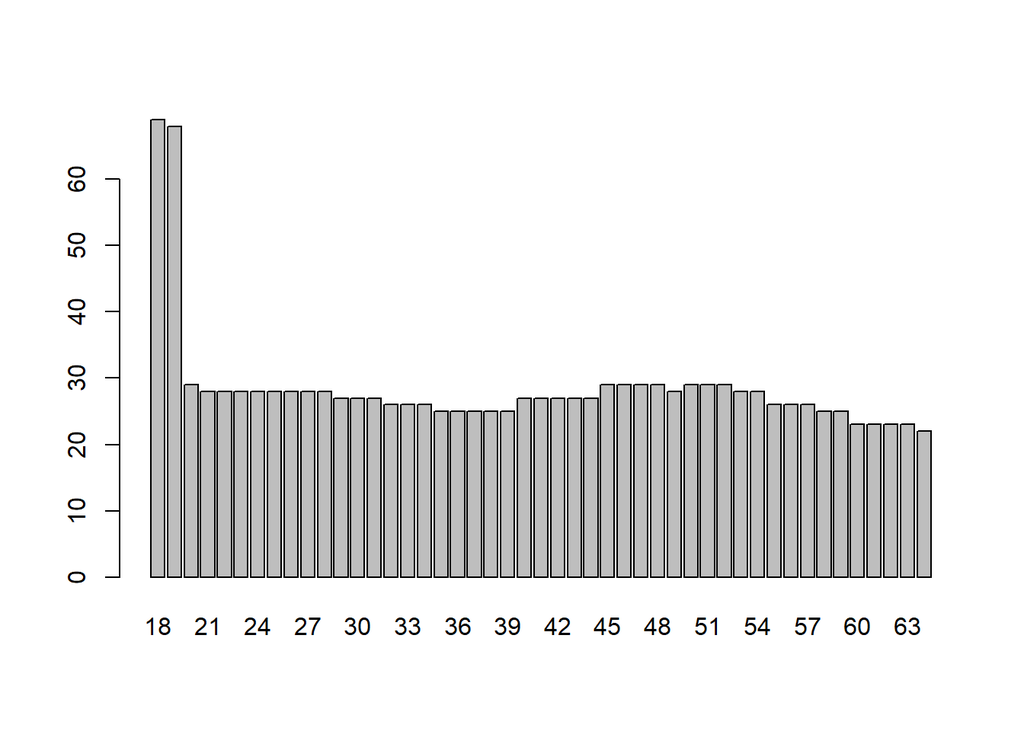

```r
barplot(table(age))
```

Độ tuổi tham gia bảo hiểm trải đều từ 18-63 tuồi.  
Trong đó, số lượng người tham gia bảo hiểm nhiều nhất tập trung ở độ tuổi 18.

### Sex

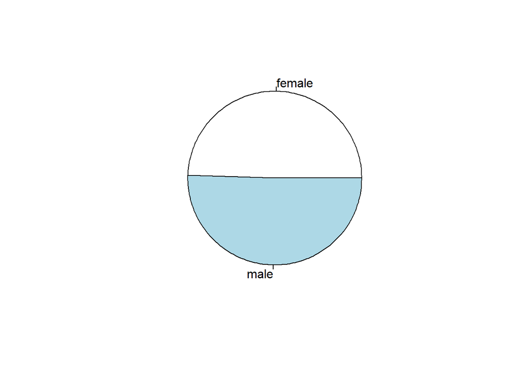

```r
pie(table(sex))
```

Nhận thấy không có sự chênh lệch về giới tính khách hàng tham gia mua bảo hiểm.

### BMI

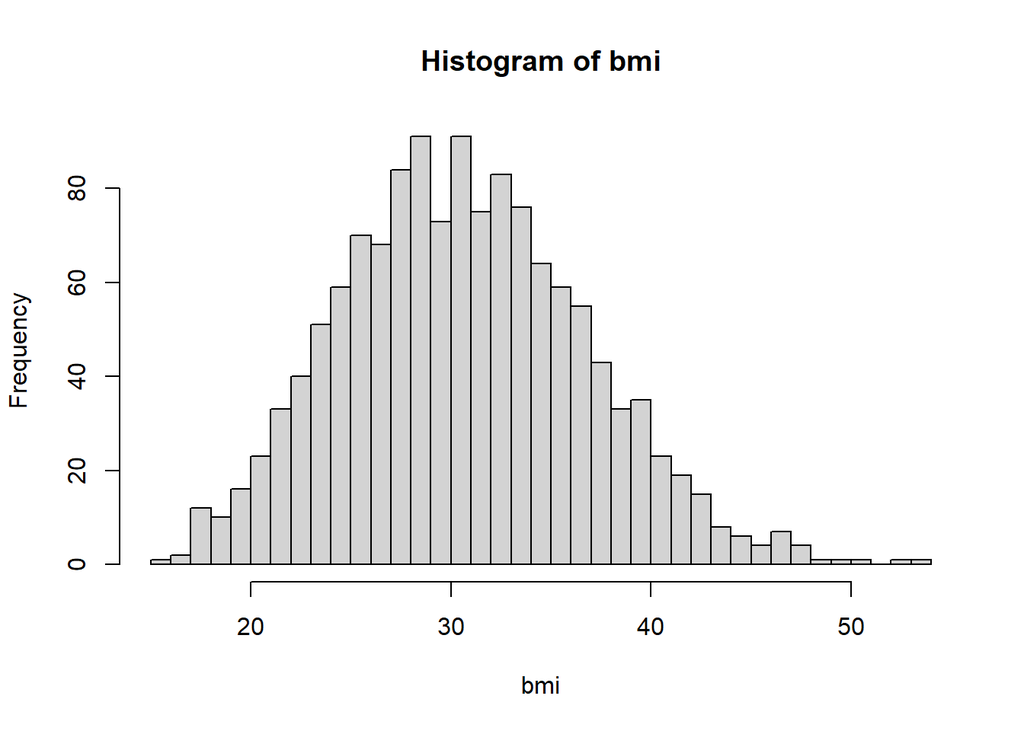

```r
hist(bmi,breaks=30)
```

#### BMI vs AGE

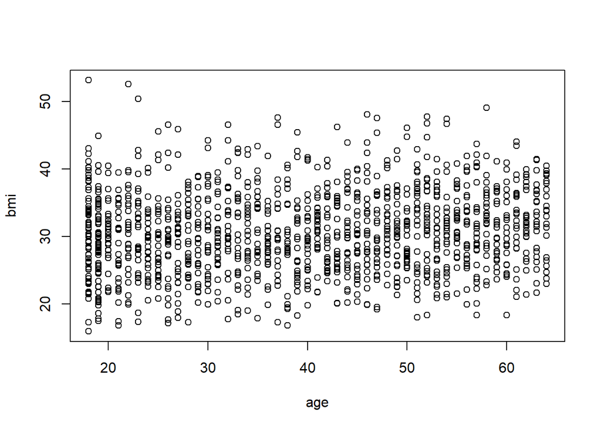

```r
plot(age,bmi)
```

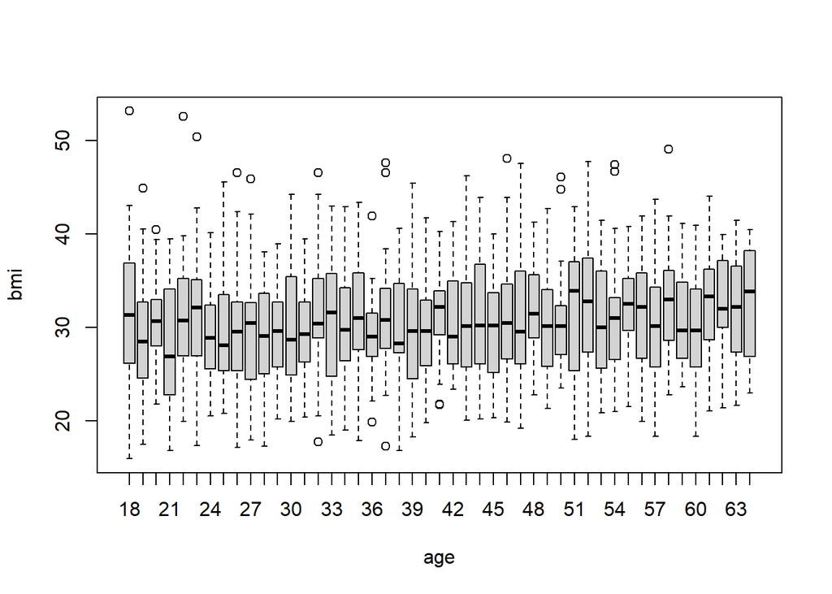

```r
boxplot(bmi~age)
```

Chỉ số bmi và age không ảnh hưởng đến nhau.  
Bmi có thể phụ thuộc vào thói quen sinh hoạt.

#### BMI vs SEX

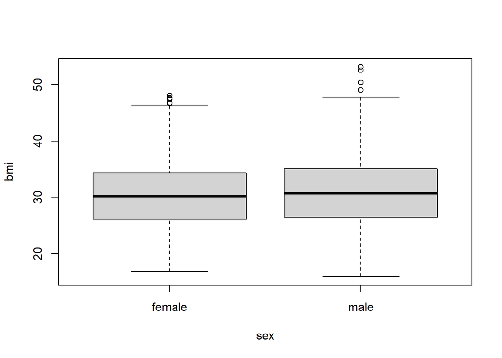

```r
boxplot(bmi~sex)
```

Chỉ số bmi và sex không ảnh hưởng đến nhau.

### Child

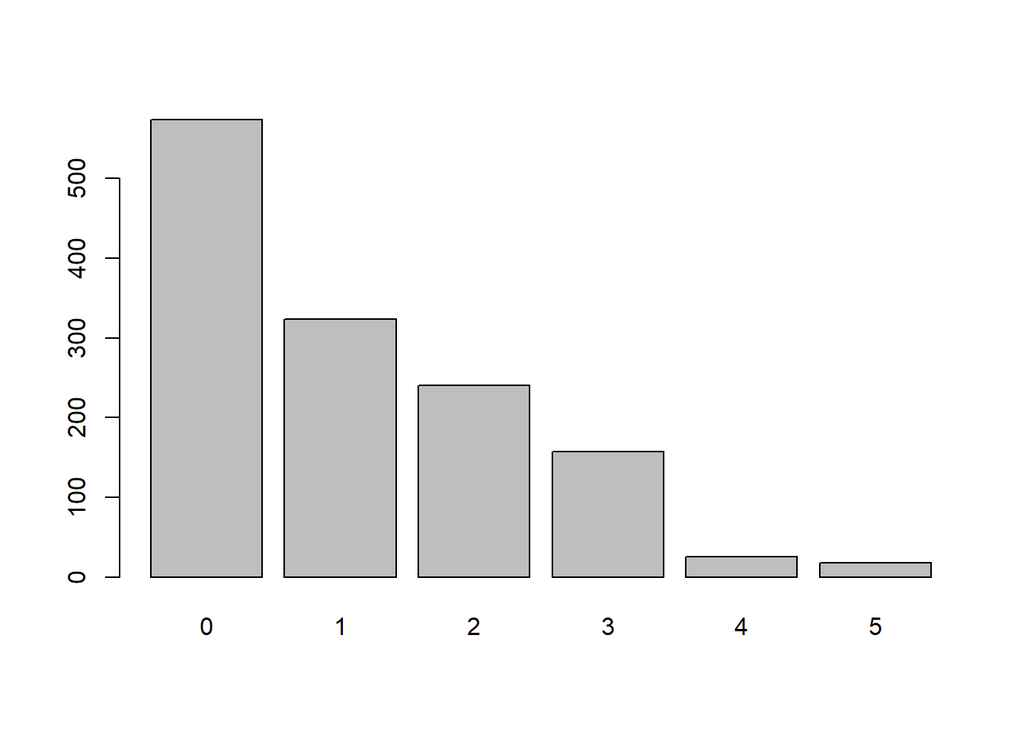

```r
barplot(table(children))
```

Chủ yếu những gia đình có ít trẻ em sẽ tham gia mua bảo hiểm nhiều hơn.  
Đặc biệt là nhóm không có trẻ em.

### Smoker

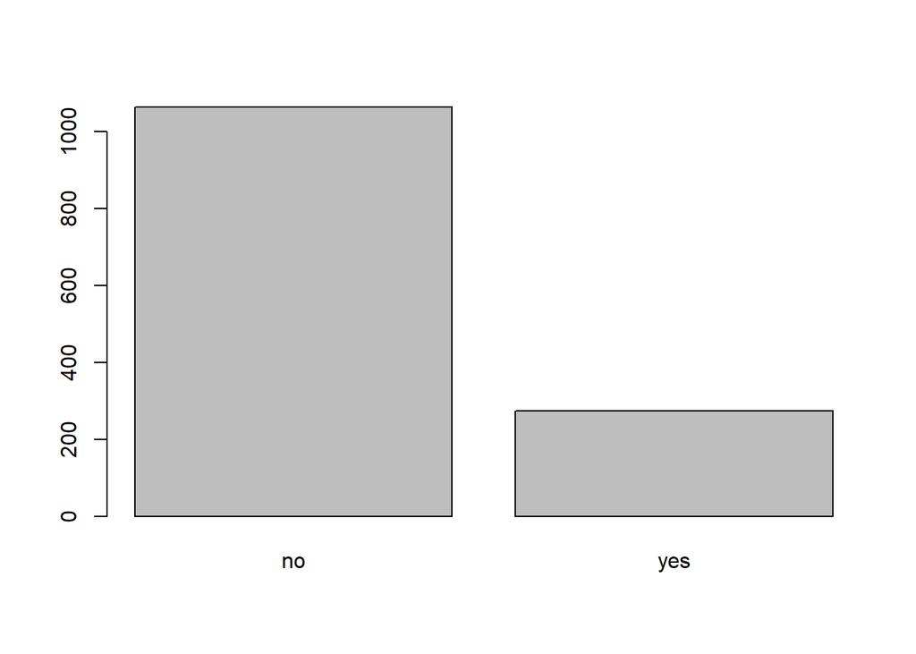

```r
barplot(table(smoker))
```

Chủ yếu người tham gia bảo hiểm là những người không hút thuốc.

### Region

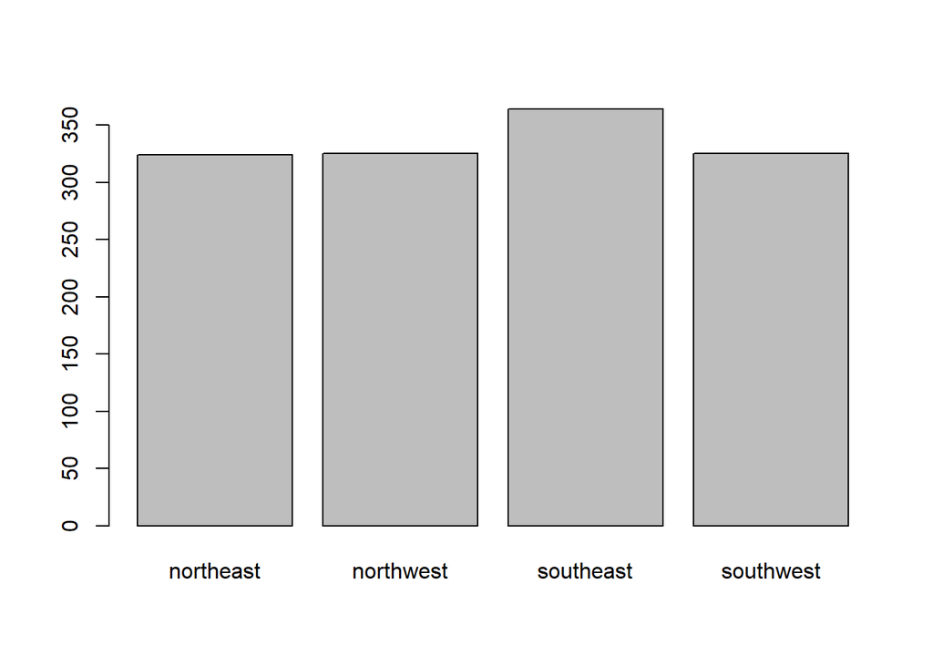

```r
barplot(table(region))
```

Khu vực sinh sống của những người đăng kí mua bảo hiểm không có sự chênh lệch.

### Charge

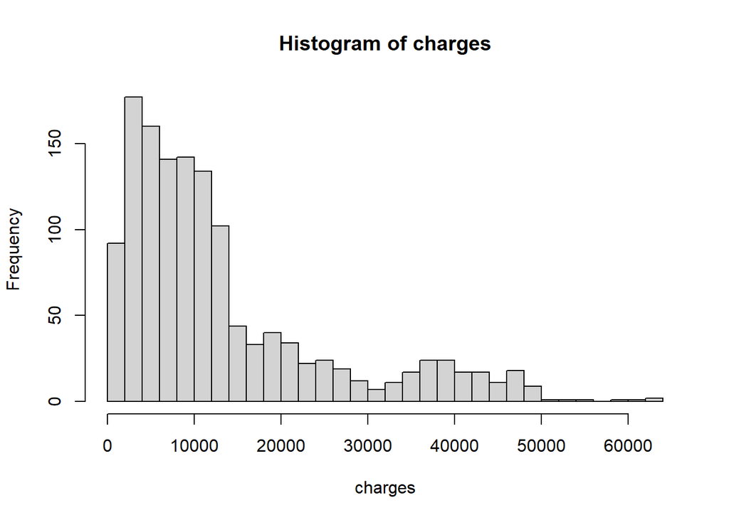

```r
hist(charges,breaks=30)
```

Chi phí bảo hiểm bị lệch về bên phải (lệch về bên nào bên đó ít).  
Xử lí: lấy log10 trên chi phí.

### ln(charge)

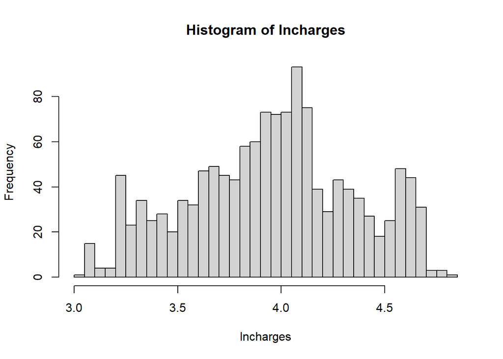

```r
lncharges <- log10(charges)
hist(lncharges,breaks=30)
```

Vẽ boxlpot kiểm tra xem có outlier không.

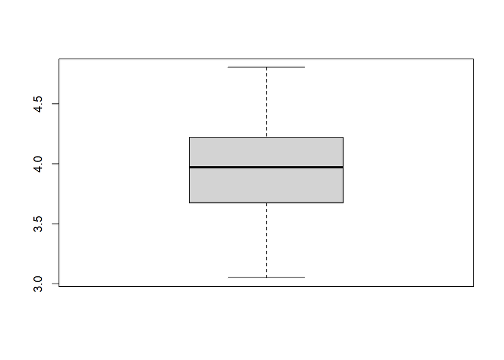

```r
boxplot(lncharges)
```

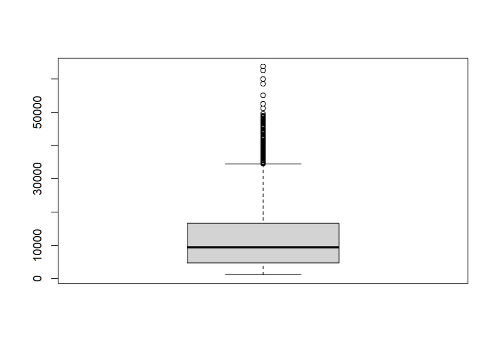

```r
boxplot(charges)
```

### ln(charges) vs age

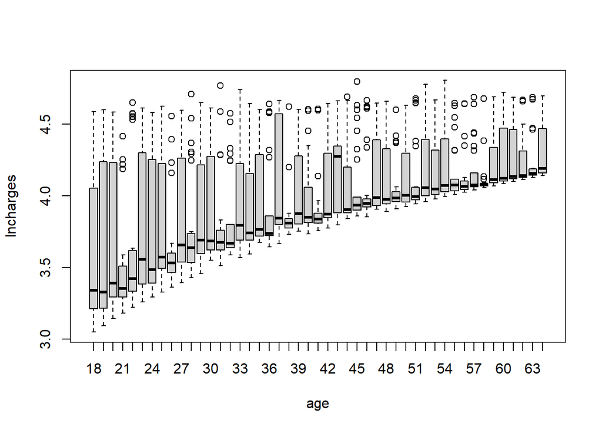

```r
boxplot(lncharges~age)
```

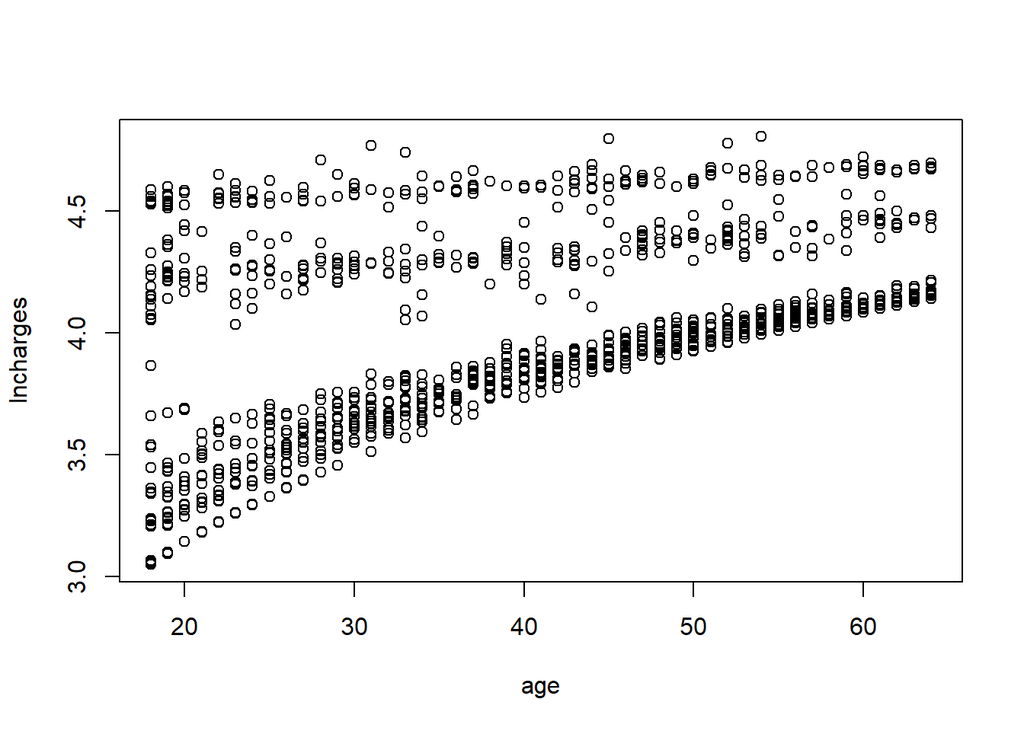

```r
plot(age,lncharges)
```

Tuổi càng cao, chi phí bảo hiểm càng tăng -> Tương quan thuận

### ln(charges) vs sex

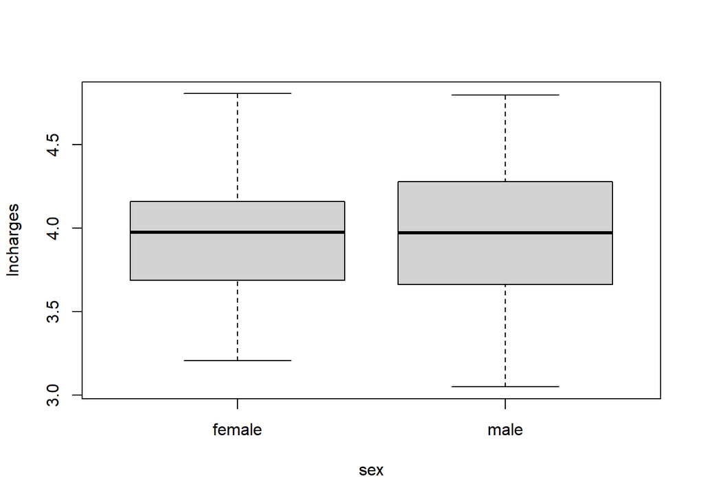

```r
boxplot(lncharges~sex)
```

Chi phí đồng bảo hiểm không ảnh hưởng bởi giới tính.

### ln(charges) vs bmi

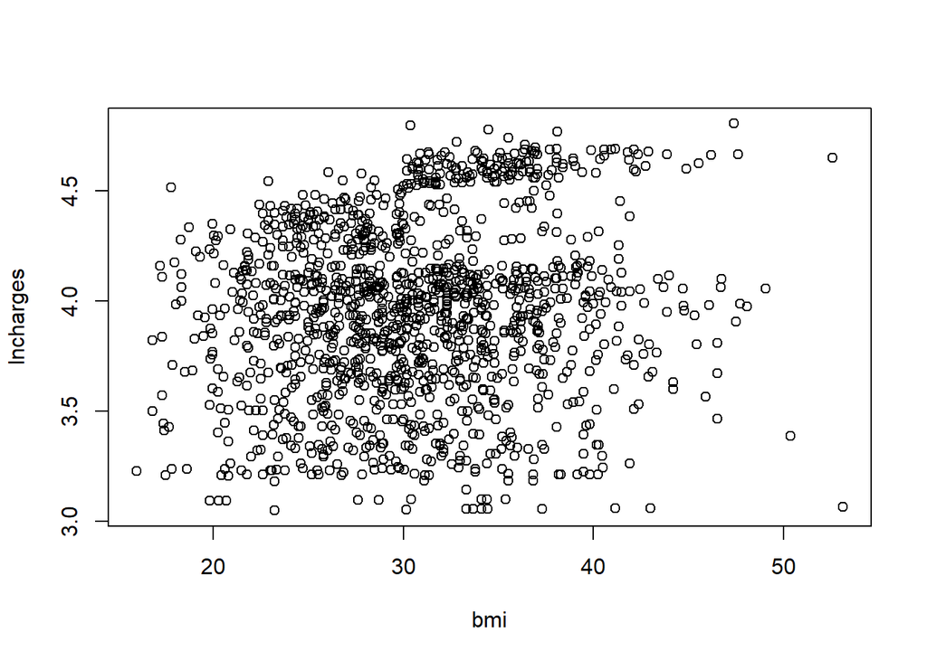

```r
plot(bmi,lncharges)
```

```r
cor(bmi,lncharges)
```

```
## [1] 0.1326694
```

Chỉ số bmi có tương quan thuận đến chi phí nhưng không nhiều.

### ln(charges) vs child

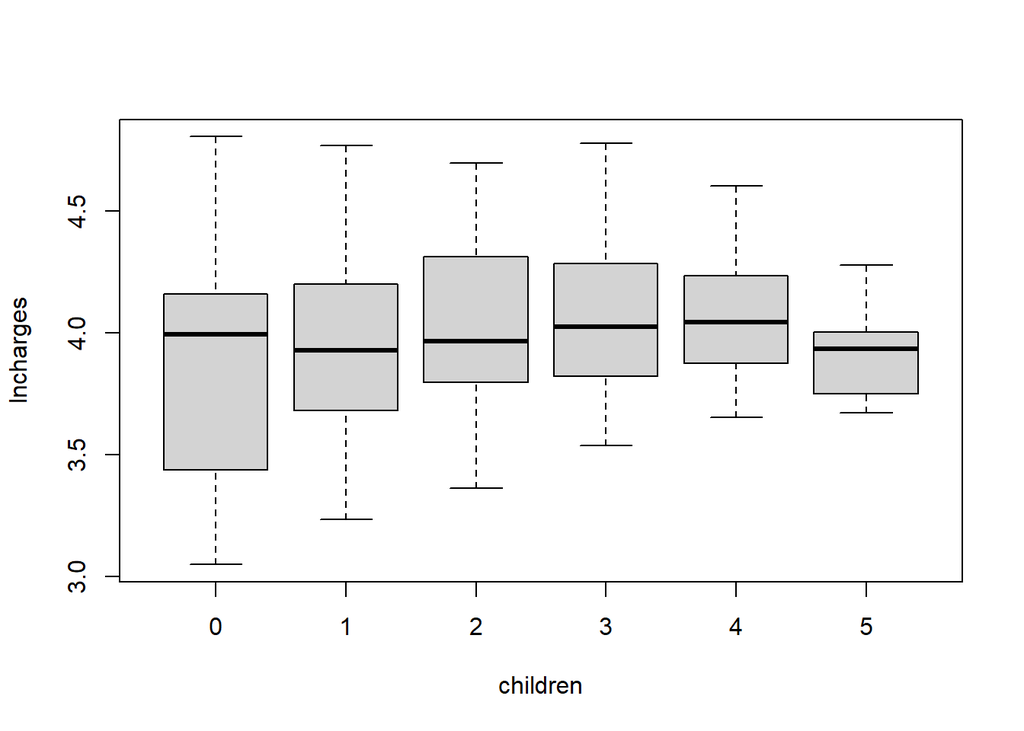

```r
boxplot(lncharges~children)
```

### ln(charges) vs region

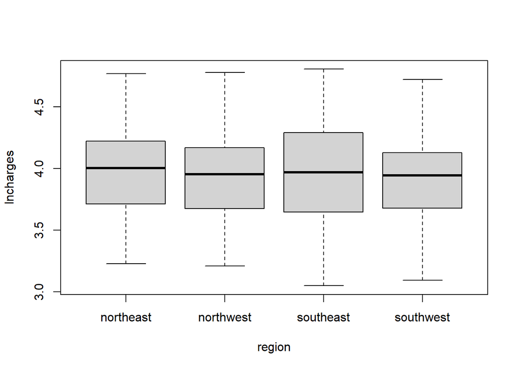

```r
boxplot(lncharges~region)
```

Chi phí đóng là như nhau ở các khu vực sinh sống khác nhau.

### bmi vs age

```r
cor(age,bmi)
```

```
## [1] 0.1092719
```

Có thể sử dụng bmi với age để đưa vào mô hình.

## Lập mô hình dự báo chi phí theo các biến bmi,age,smoker,sex,region

```r
model1 <- lm(lncharges~bmi)
summary(model1)
```

```
##
## Call:
## lm(formula = lncharges ~ bmi)
##
## Residuals:
##      Min       1Q   Median       3Q      Max
## -1.08093 -0.27593  0.01362  0.29535  0.84766
##
## Coefficients:
##             Estimate Std. Error t value Pr(>|t|)
## (Intercept) 3.685094   0.055517  66.378  < 2e-16 ***
## bmi         0.008688   0.001776   4.892 1.12e-06 ***
## ---
## Signif. codes:  0 '***' 0.001 '**' 0.01 '*' 0.05 '.' 0.1 ' ' 1
##
## Residual standard error: 0.396 on 1336 degrees of freedom
## Multiple R-squared:  0.0176, Adjusted R-squared:  0.01687
## F-statistic: 23.94 on 1 and 1336 DF,  p-value: 1.117e-06
```

Vì $R^2$ của mô hình rất thấp nên ta sẽ bổ sung các biến mới vào mô hình.

### Lập mô hình ln(charges) theo bmi,age

```r
model2 <- lm(lncharges~bmi+age)
summary(model2)
```

```
##
## Call:
## lm(formula = lncharges ~ bmi + age)
##
## Residuals:
##     Min      1Q  Median      3Q     Max
## -0.6843 -0.1938 -0.1252  0.2296  0.9048
##
## Coefficients:
##              Estimate Std. Error t value Pr(>|t|)
## (Intercept) 3.2201207  0.0517849  62.183  < 2e-16 ***
## bmi         0.0049703  0.0015254   3.258  0.00115 **
## age         0.0147670  0.0006621  22.304  < 2e-16 ***
## ---
## Signif. codes:  0 '***' 0.001 '**' 0.01 '*' 0.05 '.' 0.1 ' ' 1
##
## Residual standard error: 0.3381 on 1335 degrees of freedom
## Multiple R-squared:  0.2843, Adjusted R-squared:  0.2832
## F-statistic: 265.2 on 2 and 1335 DF,  p-value: < 2.2e-16
```

Mô hình cải thiện.  
Bổ sung thêm các biến smoker,sex.

### Lập mô hình ln(charges) theo bmi,age,smoker,sex

```r
model3 <- lm(lncharges~bmi+age+smoker+sex)
summary(model3)
```

```
##
## Call:
## lm(formula = lncharges ~ bmi + age + smoker + sex)
##
## Residuals:
##      Min       1Q   Median       3Q      Max
## -0.51720 -0.09151 -0.01693  0.04300  0.91499
##
## Coefficients:
##               Estimate Std. Error t value Pr(>|t|)
## (Intercept)  3.0843373  0.0313263  98.458  < 2e-16 ***
## bmi          0.0048015  0.0009104   5.274 1.55e-07 ***
## age          0.0152369  0.0003949  38.583  < 2e-16 ***
## smokeryes    0.6742349  0.0136972  49.224  < 2e-16 ***
## sexmale     -0.0307507  0.0110674  -2.778  0.00554 **
## ---
## Signif. codes:  0 '***' 0.001 '**' 0.01 '*' 0.05 '.' 0.1 ' ' 1
##
## Residual standard error: 0.2015 on 1333 degrees of freedom
## Multiple R-squared:  0.7461, Adjusted R-squared:  0.7453
## F-statistic: 979.1 on 4 and 1333 DF,  p-value: < 2.2e-16
```

$R^2$ của mô hình cải thiện hơn nhiều, p-value của các hệ số đều có ý nghĩa.  
Cân nhắc tới việc thêm các biến tương tác.

### Thêm biến bmi*sex

```r
gender <- replicate(length(sex),0)
for(i in 1:length(gender)){
  if(sex[i]=="male")
    gender[i]=1
  else
    gender[i]=0
}
bmi_sex <- bmi*gender
model4 <- lm(lncharges~bmi+age+gender+smoker+bmi_sex)
summary(model4)
```

```
##
## Call:
## lm(formula = lncharges ~ bmi + age + gender + smoker + bmi_sex)
##
## Residuals:
##      Min       1Q   Median       3Q      Max
## -0.53040 -0.09145 -0.01726  0.04402  0.91225
##
## Coefficients:
##              Estimate Std. Error t value Pr(>|t|)
## (Intercept)  3.103264   0.042395  73.199  < 2e-16 ***
## bmi          0.004186   0.001301   3.218  0.00132 **
## age          0.015233   0.000395  38.562  < 2e-16 ***
## gender      -0.067564   0.056639  -1.193  0.23312
## smokeryes    0.673739   0.013721  49.105  < 2e-16 ***
## bmi_sex      0.001202   0.001814   0.663  0.50761
## ---
## Signif. codes:  0 '***' 0.001 '**' 0.01 '*' 0.05 '.' 0.1 ' ' 1
##
## Residual standard error: 0.2016 on 1332 degrees of freedom
## Multiple R-squared:  0.7461, Adjusted R-squared:  0.7452
## F-statistic:   783 on 5 and 1332 DF,  p-value: < 2.2e-16
```

### Thêm biến bmi*smoke

```r
smoke <- replicate(length(smoker),0)
for(i in 1:length(smoke)){
  if(smoker[i]=="yes")
    smoke[i]=1
  else
    smoke[i]=0
}

bmi_smoke <- bmi*smoke
model5 <- lm(lncharges~bmi+age+gender+smoke+bmi_smoke)
summary(model5)
```

```
##
## Call:
## lm(formula = lncharges ~ bmi + age + gender + smoke + bmi_smoke)
##
## Residuals:
##      Min       1Q   Median       3Q      Max
## -0.41746 -0.08632 -0.01773  0.04001  0.93905
##
## Coefficients:
##               Estimate Std. Error t value Pr(>|t|)
## (Intercept)  3.2129199  0.0335403  95.793  < 2e-16 ***
## bmi          0.0005647  0.0009992   0.565 0.572044
## age          0.0153299  0.0003835  39.974  < 2e-16 ***
## gender      -0.0356514  0.0107571  -3.314 0.000944 ***
## smoke        0.0822183  0.0664902   1.237 0.216473
## bmi_smoke    0.0193041  0.0021243   9.087  < 2e-16 ***
## ---
## Signif. codes:  0 '***' 0.001 '**' 0.01 '*' 0.05 '.' 0.1 ' ' 1
##
## Residual standard error: 0.1956 on 1332 degrees of freedom
## Multiple R-squared:  0.7609, Adjusted R-squared:   0.76
## F-statistic: 847.7 on 5 and 1332 DF,  p-value: < 2.2e-16
```

```r
step(model5)
```

```
## Start:  AIC=-4359.8
## lncharges ~ bmi + age + gender + smoke + bmi_smoke
##
##             Df Sum of Sq     RSS     AIC
## - bmi        1     0.012  50.997 -4361.5
## - smoke      1     0.059  51.043 -4360.3
## <none>                    50.984 -4359.8
## - gender     1     0.420  51.405 -4350.8
## - bmi_smoke  1     3.161  54.145 -4281.3
## - age        1    61.164 112.148 -3307.0
##
## Step:  AIC=-4361.48
## lncharges ~ age + gender + smoke + bmi_smoke
##
##             Df Sum of Sq     RSS     AIC
## - smoke      1     0.046  51.043 -4362.3
## <none>                    50.997 -4361.5
## - gender     1     0.418  51.414 -4352.6
## - bmi_smoke  1     4.279  55.275 -4255.7
## - age        1    62.107 113.104 -3297.7
##
## Step:  AIC=-4362.26
## lncharges ~ age + gender + bmi_smoke
##
##             Df Sum of Sq     RSS     AIC
## <none>                    51.043 -4362.3
## - gender     1     0.432  51.475 -4353.0
## - age        1    62.063 113.105 -3299.7
## - bmi_smoke  1   102.714 153.756 -2888.8
```

```
##
## Call:
## lm(formula = lncharges ~ age + gender + bmi_smoke)
##
## Coefficients:
## (Intercept)          age       gender    bmi_smoke
##     3.23072      0.01534     -0.03610      0.02188
```